# Non-parametric Models (part II - CART)

Ryan Miller

## Non-parametric methods

The goal in supervised learning is to model/predict an outcome variable $Y$ using a set of inputs, to do so we adopt the following framework:

$$Y = f(\mathbf{X}) + \epsilon$$

- **Non-parametric methods**, do not impose any particular structure on $f$, instead applying an algorithm for generating an $\hat{f}$
  - These methods often provide high flexibility
  - We previously saw this with $k$-nearest neighbors and its tendency to overfit the data

## Classification and Regression Trees (CART)

- An extremely intuitive non-parametric approach to predicting any type of outcome is to apply a series of decision rules
  - For example, *predict “Yes” if $X_1$ is less than 5 and $X_2$ is greater than zero, otherwise predict “No”*
  - These rules can be organized into a tree-structure

## Example - Sale Price vs. Living Area

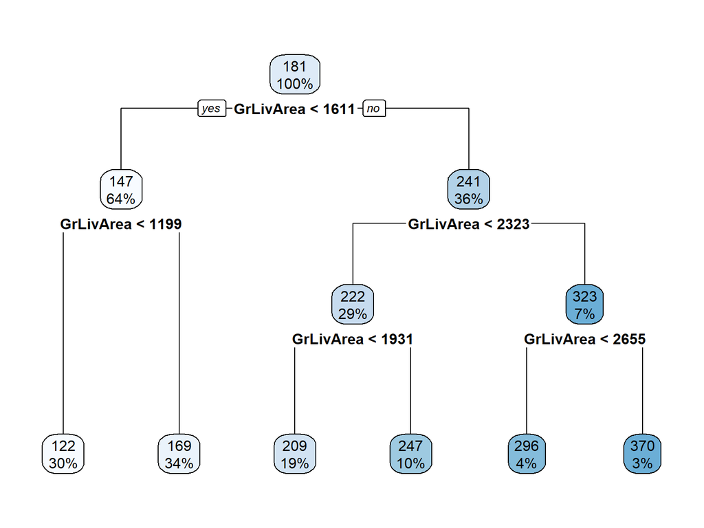

## Example - Central Air vs. Sale Price and Living Area

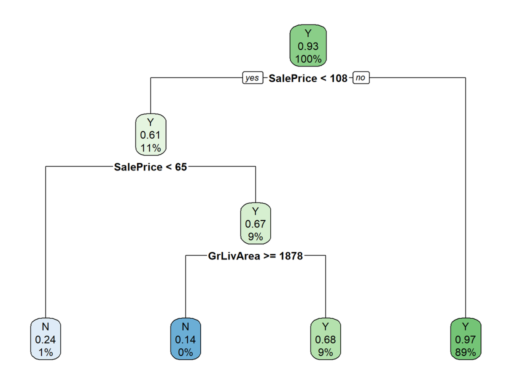

## How are these splits determined?

CART uses a procedure known as **recursive binary splitting**, you can view this as an algorithm:

1. Starting with the full dataset, search for the splitting rule that maximizes “accuracy” in the resulting nodes
2. Considering each node separately, search for another splitting rule that maximizes “accuracy” in the resulting sub-nodes
3. Repeat until a suitable level of “purity” is reached (or until additional splits fail to sufficiciently improve accuracy)

For more information on splitting and stopping rules see: https://en.wikipedia.org/wiki/Decision_tree_learning or http://pages.stat.wisc.edu/~loh/treeprogs/guide/wires11.pdf

## Comparison vs. kNN and Linear Regression

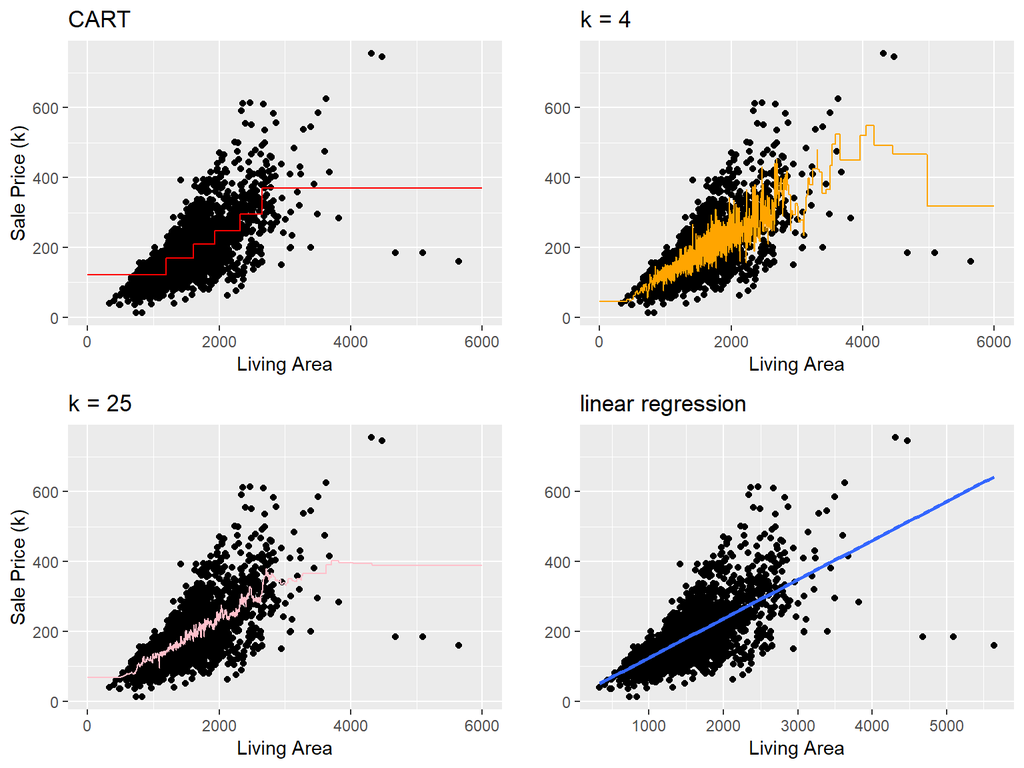

## Comparison vs. kNN and Linear Regression

```r
tctrl <- trainControl(method="repeatedcv", number = 5, repeats = 10)

set.seed(123)
fit1 <- train(SalePrice ~ GrLivArea, data = houses, method = "knn", trControl = tctrl)

set.seed(123)
fit2 <- train(SalePrice ~ GrLivArea, data = houses, method = "lm", trControl = tctrl)

set.seed(123)
fit3 <- train(SalePrice ~ GrLivArea, data = houses, method = "rpart", trControl = tctrl)

rs <- resamples(list(KNN = fit1, LM = fit2, CART = fit3))
summary(rs)
```

```
##
## Call:
## summary.resamples(object = rs)
##
## Models: KNN, LM, CART
## Number of resamples: 50
##
## MAE
##          Min.  1st Qu.   Median     Mean  3rd Qu.     Max. NA's
## KNN  36.16221 39.09256 40.37321 40.47646 41.76735 45.54723    0
## LM   34.65713 37.20439 38.33517 38.58437 39.80501 43.97965    0
## CART 37.92596 40.65532 43.14740 42.56253 44.10364 48.43659    0
##
## RMSE
##          Min.  1st Qu.   Median     Mean  3rd Qu.     Max. NA's
## KNN  51.95457 56.39007 58.59176 58.67823 61.48797 68.07926    0
## LM   49.16989 53.32104 56.24586 56.50941 59.22012 69.49545    0
## CART 53.02383 56.58240 59.80864 60.36740 63.62929 69.89185    0
##
## Rsquared
##           Min.   1st Qu.    Median      Mean   3rd Qu.      Max. NA's
## KNN  0.3881756 0.4504749 0.4640237 0.4661917 0.4861114 0.5149865    0
## LM   0.4174403 0.4777914 0.5089635 0.5032024 0.5280552 0.5645982    0
## CART 0.3547638 0.4101462 0.4311943 0.4305028 0.4537468 0.4920126    0
```

## Comparison vs. kNN and Logistic Regression

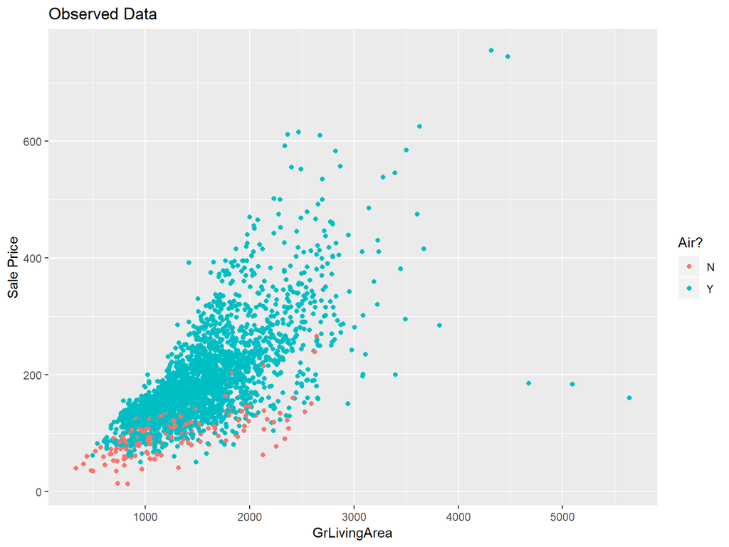

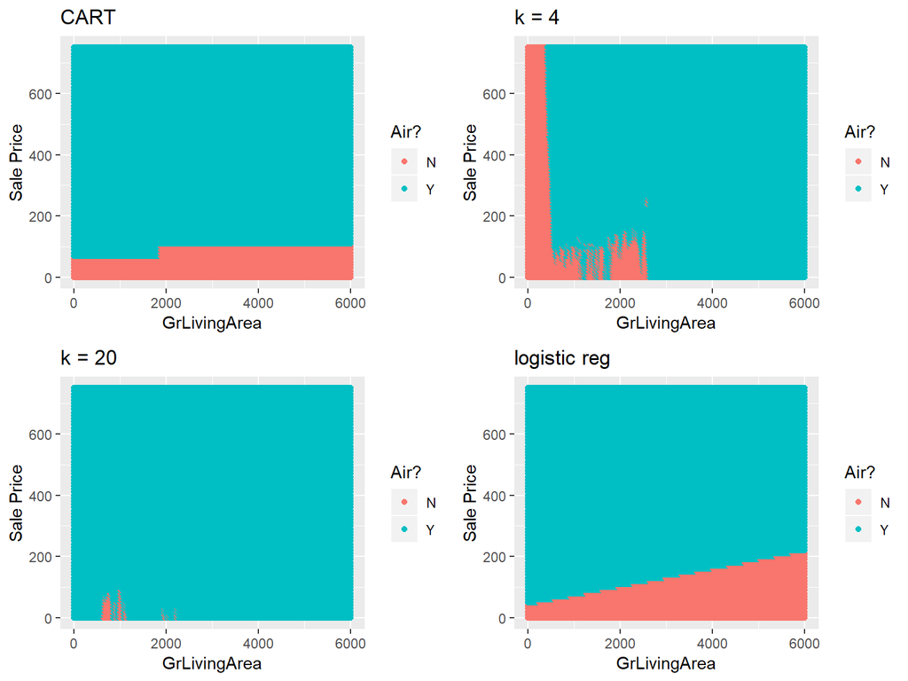

## Comparison vs. kNN and Logistic Regression

```r
ctrl <- trainControl(method="repeatedcv", number = 5, repeats = 10,
                            summaryFunction = twoClassSummary, classProbs = TRUE)

set.seed(123)
fit1 <- train(CentralAir ~ GrLivArea + SalePrice, data = houses, method = "knn", trControl = ctrl)

set.seed(123)
fit2 <- train(CentralAir ~ GrLivArea + SalePrice, data = houses, method = "glm", trControl = ctrl)

set.seed(123)
fit3 <- train(CentralAir ~ GrLivArea + SalePrice, data = houses, method = "rpart", trControl = ctrl)


rs <- resamples(list(KNN = fit1, GLM = fit2, CART = fit3))
summary(rs)
```

```
##
## Call:
## summary.resamples(object = rs)
##
## Models: KNN, GLM, CART
## Number of resamples: 50
##
## ROC
##           Min.   1st Qu.    Median      Mean   3rd Qu.      Max. NA's
## KNN  0.6995658 0.7891998 0.8200206 0.8143726 0.8440906 0.9102834    0
## GLM  0.8471382 0.8854123 0.9043266 0.9021320 0.9203227 0.9466085    0
## CART 0.6250879 0.7279879 0.7682567 0.7659175 0.8017684 0.9068814    0
##
## Sens
##            Min.   1st Qu.    Median      Mean   3rd Qu.      Max. NA's
## KNN  0.07692308 0.1500000 0.1538462 0.1718590 0.2000000 0.3076923    0
## GLM  0.10000000 0.1538462 0.2025641 0.2005385 0.2307692 0.3333333    0
## CART 0.07692308 0.2051282 0.2532051 0.2535385 0.2820513 0.4615385    0
##
## Spec
##           Min.   1st Qu.    Median      Mean   3rd Qu.      Max. NA's
## KNN  0.9817185 0.9894839 0.9926874 0.9925754 0.9945155 1.0000000    0
## GLM  0.9780220 0.9872029 0.9890311 0.9896855 0.9926874 0.9963437    0
## CART 0.9616088 0.9798903 0.9853748 0.9844190 0.9903896 1.0000000    0
```

## Conclusion

- Classification and regression trees are flexible and easy to interpret
- Like k-nearest neighbors, their flexibility makes them prone towards overfitting
- Soon we’ll cover a “black-box” extension of trees known as *random forests* that effectively addresses this issue, allowing for excellent prediction